# hough_transform

2024-11-23

# Hough Transform 学习笔记

## Image and parameter space

先定义一个工具函数，方便画出网格线和坐标系

```python
import numpy as np
import matplotlib.pyplot as plt
from typing import List, Tuple
from PIL import Image
import cv2

def plot_points_and_lines_with_grid(
    ax: plt.Axes,
    ax_labels = ["x", "y"],
    scatter_arg_kwarg_pair: Tuple = None,
    line_arg_kwarg_pairs: List[Tuple] = None,
    limits: List[int] = [-5, 5, -5, 5]
):
    """_summary_

    https://stackoverflow.com/questions/13430231/how-i-can-get-cartesian-coordinate-system-in-matplotlib

    Args:
        ax (_type_): _description_
        scatter_arg_kwarg_pair (Tuple, optional): _description_. Defaults to None.
        line_arg_kwarg_pairs (List[Tuple], optional): _description_. Defaults to None.
        label_size (int, optional): _description_. Defaults to 14.

    Returns:
        _type_: _description_
    """

    # Plot points
    if scatter_arg_kwarg_pair is not None:
        scatter_args, scatter_kwargs = scatter_arg_kwarg_pair
        ax.scatter(*scatter_args, **scatter_kwargs)

    # Plot lines
    if line_arg_kwarg_pairs is not None:
        for line_args, line_kwargs in line_arg_kwarg_pairs:
            ax.plot(*line_args, **line_kwargs)

    # Select length of axes and the space between tick labels
    xmin, xmax, ymin, ymax = limits
    ticks_frequency = 1

    # Set identical scales for both axes
    ax.set(xlim=(xmin-1, xmax+1), ylim=(ymin-1, ymax+1), aspect='equal')

    # Set bottom and left spines as x and y axes of coordinate system
    ax.spines['bottom'].set_position('zero')
    ax.spines['left'].set_position('zero')

    # Remove top and right spines
    ax.spines['top'].set_visible(False)
    ax.spines['right'].set_visible(False)

    # Create 'x' and 'y' labels placed at the end of the axes
    ax.set_xlabel(ax_labels[0], size=14, labelpad=-24, x=1.03)
    ax.set_ylabel(ax_labels[1], size=14, labelpad=-21, y=1.02, rotation=0)

    # Create custom major ticks to determine position of tick labels
    x_ticks = np.arange(xmin, xmax+1, ticks_frequency)
    y_ticks = np.arange(ymin, ymax+1, ticks_frequency)
    ax.set_xticks(x_ticks[x_ticks != 0])
    ax.set_yticks(y_ticks[y_ticks != 0])

    # Create minor ticks placed at each integer to enable drawing of minor grid
    # lines: note that this has no effect in this example with ticks_frequency=1
    ax.set_xticks(np.arange(xmin, xmax+1), minor=True)
    ax.set_yticks(np.arange(ymin, ymax+1), minor=True)

    # Draw major and minor grid lines
    ax.grid(which='both', color='grey', linewidth=1, linestyle='-', alpha=0.2)

    return ax
```

### Image Space and Parameter Space

**Image space**

在 Image Space 中，我们将一条直线表示为：

$$y = mx + b$$

其中$m$和$b$为 parameters，$x$和$y$为 variables

**Parameter Space**

在 Parameter Space 中，我们将一条直接表示为：

$$y - mx = b$$

其中$x$和$y$为 parameters，$m$和$b$为 variables

```python
def line_image_space(x, m, b):
    return m * x + b

def line_parameter_space(m, x, y):
    return y - m * x
```

### A line becomes a point

下图中，我们将一个 image space 的直线转化为 parameter space 中的一个点：

- Image Space 直线的斜率 `m` 对应 Parameter Space 中点的横轴坐标 `m`
- Image Space 直线的截距 `b` 坐标对应 Parameter Space 中点的纵轴坐标 `b`

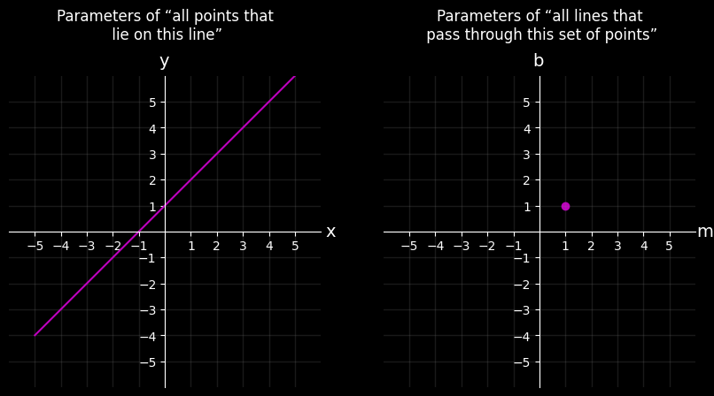

png

```python
nums = np.linspace(-5, 5, 11)

fig, ax = plt.subplots(1, 2, figsize=(10, 5))

# Plot On Image Space
b = 1
m = 1
x = nums.copy()
y = line_image_space(x, m, b)

ax[0].set_title("Parameters of “all points that\n lie on this line”", pad=30)
plot_points_and_lines_with_grid(
    ax[0],
    line_arg_kwarg_pairs = [
        [(x, y), {"color": "m"}]
    ]
)

# Plot On Parameter Space
ax[1].set_title("Parameters of “all lines that\n pass through this set of points”", pad = 30)
plot_points_and_lines_with_grid(
    ax[1],
    scatter_arg_kwarg_pair = [(), {
        "x": [m],
        "y": [b],
        "c": ["m"],
    }],
    ax_labels = ['m', 'b']
)
plt.show()
```

### A Point becomes a line

回顾 Image Space： $y = mx + b$，Parameter Space： $y - mx = b$

下图中，我们将一个 image space 的点转化为 parameter space 中的一条直线：

- Image Space 点的 `x` 坐标对应 Parameter Space 中直线的斜率 `-x`，
- Image Space 点的 `y` 坐标变成 Parameter Space 中直线的截距 `y`

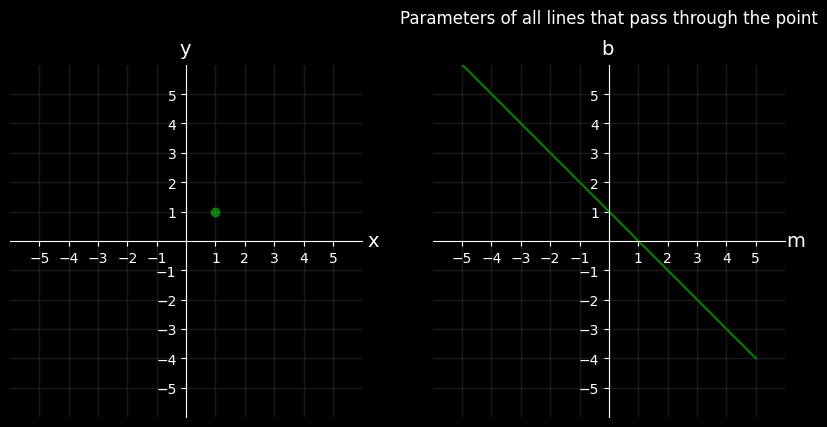

png

```python
fig, ax = plt.subplots(1, 2, figsize=(10, 5))

# Point On Image Space
image_space_point = [1, 1]

plot_points_and_lines_with_grid(
    ax[0],
    scatter_arg_kwarg_pair = [(), {
        "x": [image_space_point[0]],
        "y": [image_space_point[1]],
        "c": ["g"],
    }]
)

# Line On Parameter Space
m = nums.copy()
x, y = image_space_point
b = line_parameter_space(m, x, y)

ax[1].set_title("Parameters of all lines that pass through the point", pad = 30)

plot_points_and_lines_with_grid(
    ax[1],
    line_arg_kwarg_pairs = [
        [(m, b), {"color": "g"}]
    ],
    ax_labels = ['m', 'b']
)

plt.show()
```

### Four points becomes?

回顾 Image Space： $y = mx + b$，Parameter Space： $y - mx = b$

下图中，我们将4个来自 image space 的点，转换为 parameter space 中的直线

- Image Space 点的 `x` 坐标对应 Parameter Space 中直线的斜率 `-x`，
- Image Space 点的 `y` 坐标变成 Parameter Space 中直线的截距 `y`

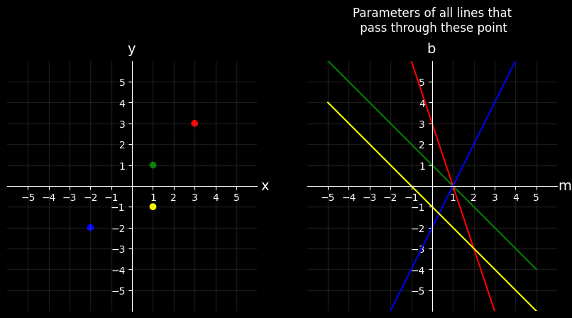

png

```python
fig, ax = plt.subplots(1, 2, figsize=(10, 5))

# Plot On Image Space
pts = [[1, 1], [3, 3], [-2, -2], [1, -1]]
colors = ["green", "red", "blue", "yellow"]

xs = [pt[0] for pt in pts]
ys = [pt[1] for pt in pts]

plot_points_and_lines_with_grid(
    ax[0],
    scatter_arg_kwarg_pair = [(), {
        "x": xs,
        "y": ys,
        "c": colors,
    }]
)

# Plot On Parameter Space
# x, y = image_space_point

line_arg_kwarg_pairs = [[(nums.copy(), line_parameter_space(nums.copy(), x, y)), {"color": color}] for x, y, color in zip(xs, ys, colors)]

ax[1].set_title("Parameters of all lines that\n pass through these point", pad = 30)
plot_points_and_lines_with_grid(
    ax[1],
    line_arg_kwarg_pairs = line_arg_kwarg_pairs,
    ax_labels = ['m', 'b']
)

plt.show()
```

## Line Detection by Hough Transform

Key idea: points **vote** for the possible models

1. Quantize Parameter Space $(m, c)$
2. Create Accumulator Array $A(m, c)$
3. Set $A(m, c)=0 \quad \forall m, c$
4. For each image edge $\left(x_i, y_i\right)$
   - For each element in $A(m, c)$
   - If $(m, c)$ lies on the line: $c=-x_i m+y_i$
     - Increment $A(m, c)=A(m, c)+1$
5. Find local maxima in $A(m, c)$

遍历边缘图中的点： - 参数空间中由slope $m$ 和intercept $c$ 组成，构成一条条直线方程 - 将边缘图中的点的坐标（x,y）代入方程之中，计算 $b = y - mx$ - 如果 $b$ 与 $c$ 相等，则说明点在直线上，投票 +1

准备宽高为`(11, 11)`的edge图，以其中心点为原点，将`[[1, 1], [3, 3], [-2, -2], [1, -1]]`这四个点移动到相应位置

```python
edge_img = np.zeros((11, 11), dtype=np.uint8)
offset = 5
# origin_ij = (5, 5)
pts = [[1, 1], [3, 3], [-2, -2], [1, -1]]
pts = np.array(pts) + 5

for i, j in pts:
    edge_img[i, j] = 255

# Image.fromarray(cv2.resize(edge_img, (110, 110), interpolation=cv2.INTER_NEAREST))

print(pts.tolist())
```

```
[[6, 6], [8, 8], [3, 3], [6, 4]]
```

移动之后，如下图所示

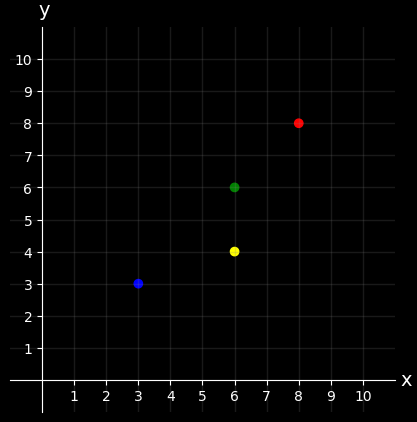

png

```python
fig, ax = plt.subplots(figsize=(5, 5))

# Plot On Image Space
colors = ["green", "red", "blue", "yellow"]

xs = [pt[0] for pt in pts.tolist()]
ys = [pt[1] for pt in pts.tolist()]

plot_points_and_lines_with_grid(
    ax,
    scatter_arg_kwarg_pair = [(), {
        "x": xs,
        "y": ys,
        "c": colors,
    }],
    limits=[0, 10, 0, 10]
)
plt.show()
```

实现hough transform算法并根据4个点，计算出相应的直线

```python
def raw_hough_line_detection(
    edge_img,
    m_values,
    c_values,
):
    # width, height = edge_img.shape
    num_m = len(m_values)
    num_c = len(c_values)

    accumulator = np.zeros((num_m, num_c))

    y_idxs, x_idxs = np.nonzero(edge_img) # (row, col) index to edges

    for x, y in zip(x_idxs, y_idxs):
        for m_idx, m in enumerate(m_values):
            for c_idx, c in enumerate(c_values):
                if np.isclose(c, y - m * x):
                    accumulator[m_idx, c_idx] += 1

    return accumulator, m_values, c_values

m_values = np.arange(-5, 5 + 1, 1)
c_values = np.arange(-10, 10 + 1, 1)

accumulator, m_values, c_values = raw_hough_line_detection(edge_img, m_values, c_values)

idx = np.argmax(accumulator)
row = idx // len(c_values)
col = idx % len(c_values)

m, c = m_values[row], c_values[col]

print(m, c)
```

```
1 0
```

将4个点和计算出来的直线画出来

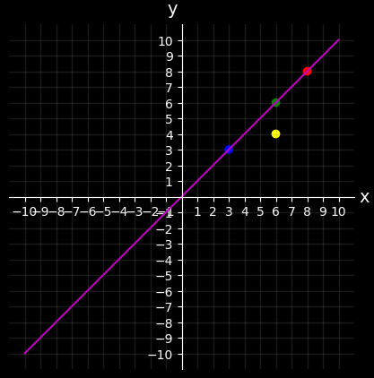

png

```python
# Plot On Image Space
points = pts.tolist()
colors = ["green", "red", "blue", "yellow"]

nums = np.arange(-10, 10+1, 1)

xs = [pt[0] for pt in points]
ys = [pt[1] for pt in points]


# Plot On Image Space
points = pts.tolist()
colors = ["green", "red", "blue", "yellow"]

xs = [pt[0] for pt in points]
ys = [pt[1] for pt in points]

nums = np.arange(-10, 10+1, 1)
x = nums.copy()
y = line_image_space(x, m, c)

fig, ax = plt.subplots(1, 1, figsize=(5, 5))

plot_points_and_lines_with_grid(
    ax,
    scatter_arg_kwarg_pair = [(), {
        "x": xs,
        "y": ys,
        "c": colors,
    }],
    line_arg_kwarg_pairs = [
        [(x, y), {"color": "m"}]
    ],
    limits=[-10, 10, -10, 10]
)

plt.show()
```

参数空间的问题

$A(m,c)$ 中 $m$ 和 $c$ 的取值范围：

$$\begin{align*}
-\infty < m < \infty \\
-\infty < c < \infty
\end{align*}$$

即$A(m,c)$是无限的

## Line Parameterizations

### Slope intercept form

$$y = mx + b$$

其中 - $m$ 是 slope - $b$ 是 y-intercept

### Double intercept form

$$\frac{x}{a} + \frac{y}{b} = 1$$

其中 - $a$ 是 x-intercept - $b$ 是 y-intercept

推导过程： 假设一条直线与x轴相交于$(a,0)$，与$y$轴相交于$(0,b)$

根据斜率相同，得到

$$\frac{y - b}{x - 0}=\frac{y - 0}{x - a}$$

然后推导

$$\begin{align*}
(y-b)(x-a) &= (y-0)(x-0) \\
yx - ya -bx + ba &= yx \\
-ya - bx + ba &= 0 \\
ya + bx &= ba \\
\frac{y}{b} + \frac{x}{a} &= 1
\end{align*}$$

最后得到

$$\frac{x}{a} + \frac{y}{b} = 1$$

### Normal form (法线式)

过原点向直线作一垂直线段，若该线长度为 $\rho$ ，且与正 $x$-轴的倾斜角为 $\theta$ ，则有方程

$$x \cos \theta + y \sin \theta = \rho$$

其中 $\cos \theta$ 和 $\sin \theta$ 可以表示为：

$$\begin{aligned}
\cos \theta & =\frac{\rho}{a} \rightarrow a=\frac{\rho}{\cos \theta} \\
\sin \theta & =\frac{\rho}{b} \rightarrow b=\frac{\rho}{\sin \theta}
\end{aligned}$$

将其代入 $\frac{x}{a} + \frac{y}{b} = 1$， 可得

$$x \cos \theta + y \sin \theta = \rho$$

## Better Parameterization

Use normal form:

$$x \cos \theta+y \sin \theta=\rho$$

Given points $\left(x_i, y_i\right)$ find $(\rho, \theta)$ that describe all lines that can pass through this point.

What is the range of $\rho, \theta$ ?

$$\begin{aligned}
& 0 \leq \theta \leq 2 \pi \\
& 0 \leq \rho \leq \rho_{\max}
\end{aligned}$$

实际应用中

- 可以限定$\theta$的取值为$[0,\pi]$，即可，因为$\theta$和$\theta + \pi$是同一直线角度的2种表述
- $\rho_{\max}$由图片大小决定，为其对角线的长度：$\sqrt{x^2 + y^2}$。

## Image Space and Parameter Space (Normal form)

在 Image Space 中，我们将一条直线表示为：

$$y = mx + b$$

其中$m$和$b$为 parameters，$x$和$y$为 variables

在 Parameter Space 中，我们将一条直线表示为法线式：

$$x \cos \theta+y \sin \theta=\rho$$

变量$x$和$y$为 parameters, $\theta$和$\rho$为 variables

```python
def normal_form_line_parameter_space(theta, x, y):
    return x * np.cos(theta) + y * np.sin(theta)
```

增加适用于法线式直线表达的方便画网格的函数

```python
def plot_points_and_lines_with_grid_theta_rho(
    ax: plt.Axes,
    ax_labels = [r"$\theta$", r"$\rho$"],
    scatter_arg_kwarg_pair: List = None,
    line_arg_kwarg_pairs: List[List] = None,
    limits: List[int] = [-0.05 * np.pi, np.pi, -4.5, 4.5]
):
    """_summary_

    https://stackoverflow.com/questions/13430231/how-i-can-get-cartesian-coordinate-system-in-matplotlib

    Args:
        ax (_type_): _description_
        scatter_arg_kwarg_pair (Tuple, optional): _description_. Defaults to None.
        line_arg_kwarg_pairs (List[Tuple], optional): _description_. Defaults to None.
        label_size (int, optional): _description_. Defaults to 14.

    Returns:
        _type_: _description_
    """
    # Plot points
    if scatter_arg_kwarg_pair is not None:
        scatter_args, scatter_kwargs = scatter_arg_kwarg_pair
        ax.scatter(*scatter_args, **scatter_kwargs)

    # Plot lines
    if line_arg_kwarg_pairs is not None:
        for line_args, line_kwargs in line_arg_kwarg_pairs:
            ax.plot(*line_args, **line_kwargs)


    # Set bottom and left spines as x and y axes of coordinate system
    # ax.spines['bottom'].set_position('zero')
    ax.spines['left'].set_position('zero')

    # Remove top and right spines
    ax.spines['top'].set_visible(False)
    ax.spines['right'].set_visible(False)

    # Select length of axes and the space between tick labels
    xmin, xmax, ymin, ymax = limits
    ticks_frequency = 1

    # Set identical scales for both axes
    ax.set(xlim=(xmin, xmax), ylim=(ymin, ymax), aspect='auto')

    # # Create 'x' and 'y' labels placed at the end of the axes
    ax.set_xlabel(ax_labels[0], size=14, labelpad=-24, x=1.03)
    ax.set_ylabel(ax_labels[1], size=14, labelpad=-21, y=1.02, rotation=0)

    # # Create custom major ticks to determine position of tick labels
    y_ticks = np.arange(int(ymin), int(ymax)+1, ticks_frequency)
    ax.set_yticks(y_ticks)

    x_tick = np.arange(0, 1, 0.25)
    x_tick_labels = [ r"$0$", r"$0.25\pi$",  r"$0.5\pi$", r"$0.75\pi$"]
    ax.set_xticks(x_tick*np.pi)
    ax.set_xticklabels(x_tick_labels, fontsize=14)

    ax.grid(which='both', color='grey', linewidth=1, linestyle='-', alpha=0.2)

    return ax
```

```python
int(-4.5), int(4.5)
```

```
(-4, 4)
```

### A point becomes a wave

对于点$(1,1)$，寻找所有经过该点的直线

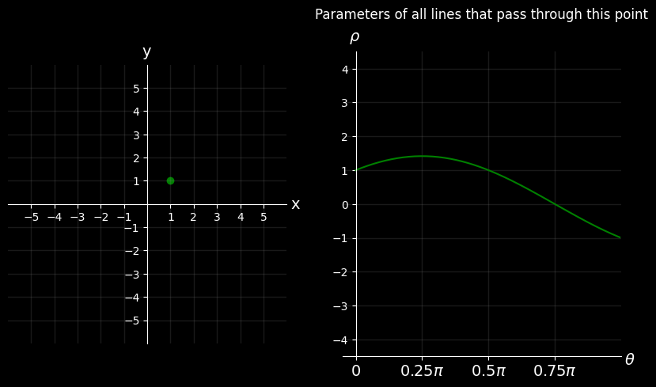

png

```python
fig, ax = plt.subplots(1,2, figsize=(10, 5))

# Point On Image Space
image_space_point = [1, 1]

plot_points_and_lines_with_grid(
    ax[0],
    scatter_arg_kwarg_pair = [(), {
        "x": [image_space_point[0]],
        "y": [image_space_point[1]],
        "c": ["g"],
    }]
)

# Line on Parameter Space
degrees = np.arange(0, 180, 1)
thetas = np.deg2rad(degrees)

rhos = normal_form_line_parameter_space(thetas, 1, 1)

ax[1].set_title("Parameters of all lines that pass through this point", pad=30)

plot_points_and_lines_with_grid_theta_rho(
    ax[1],
    line_arg_kwarg_pairs=[
        [(thetas, rhos), {"color": "g"}]
    ]
)


plt.show()
```

### A line becomes a point

对于直线 $x=1$（方向为向上），过原点向其作一垂直线段： - 与原点的距离（线段长度）： $\rho = 1$ - 线段与$x$轴的夹角为$\theta = 0$

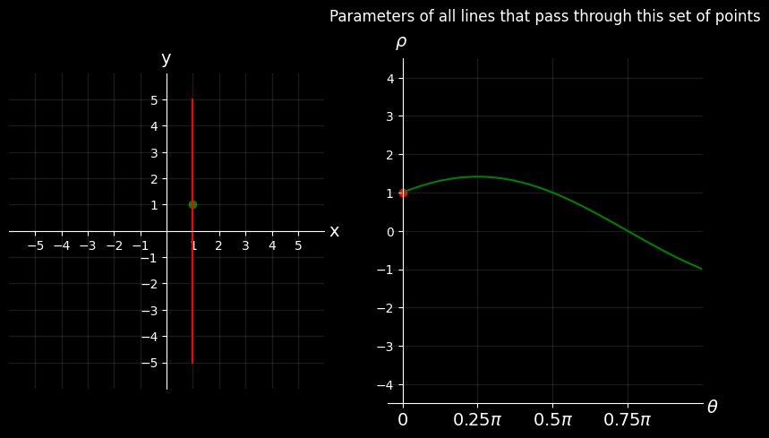

png

```python
fig, ax = plt.subplots(1,2, figsize=(10, 5))

# Point On Image Space
image_space_point = [1, 1]

xs = np.repeat(1, repeats=11)
ys = np.arange(-5, 5+1, 1)

plot_points_and_lines_with_grid(
    ax[0],
    scatter_arg_kwarg_pair = [(), {
        "x": [image_space_point[0]],
        "y": [image_space_point[1]],
        "c": ["g"],
    }],
    line_arg_kwarg_pairs=[
        [(xs, ys), {"color": "r"}]
    ]
)

# Plot on Parameter Space

degrees = np.arange(0, 180, 1)
line_thetas = np.deg2rad(degrees)

line_rhos = normal_form_line_parameter_space(line_thetas, 1, 1)

rho = 1
theta = 0

ax[1].set_title("Parameters of all lines that pass through this set of points", pad=30)

plot_points_and_lines_with_grid_theta_rho(
    ax[1],
    scatter_arg_kwarg_pair = [(), {
        "x": [theta],
        "y": [rho],
        "c": ["r"],
    }],
    line_arg_kwarg_pairs=[
        [(line_thetas, line_rhos), {"color": "g"}]
    ]
)

plt.show()
```

### A line becomes a point

对于直线 $x=-x + 2$，过原点向其作一垂直线段： - 与原点的距离（线段长度）： $\rho=\sqrt{1^2 + 1^2}$ - 线段与$x$轴的夹角为$45$度，或者说是$\theta \arccos \frac{1}{\rho}$

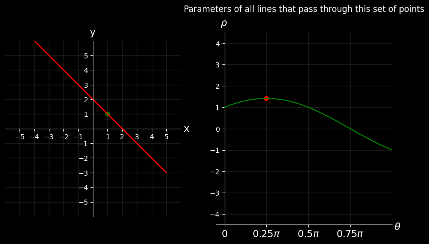

png

```python
fig, ax = plt.subplots(1,2, figsize=(10, 5))

# Point On Image Space
image_space_point = [1, 1]

xs = np.arange(-5, 5 + 1, 1)
m = -1
b = 2
ys = line_image_space(xs, m, b)

plot_points_and_lines_with_grid(
    ax[0],
    scatter_arg_kwarg_pair = [(), {
        "x": [image_space_point[0]],
        "y": [image_space_point[1]],
        "c": ["g"],
    }],
    line_arg_kwarg_pairs=[
        [(xs, ys), {"color": "r"}]
    ]
)

# Plot on Parameter Space

degrees = np.arange(0, 180, 1)
line_thetas = np.deg2rad(degrees)
line_rhos = normal_form_line_parameter_space(line_thetas, 1, 1)


rho = np.sqrt(1**2 + 1 **2)
theta = np.arccos(1/rho)

ax[1].set_title("Parameters of all lines that pass through this set of points", pad=30)

plot_points_and_lines_with_grid_theta_rho(
    ax[1],
    scatter_arg_kwarg_pair = [(), {
        "x": [theta],
        "y": [rho],
        "c": ["r"],
    }],
    line_arg_kwarg_pairs=[
        [(line_thetas, line_rhos), {"color": "g"}]
    ]
)

plt.show()
```

### A line becomes a point

对于直线 $y=1$，过原点向其作一垂直线段： - 与原点的距离（线段长度）： $\rho=1$ - 线段与$x$轴的夹角为$90$度，或者说是$\theta = \arccos \frac{0}{1}$，使用Python计算 `np.deg2rad(90) == np.arccos(0)`

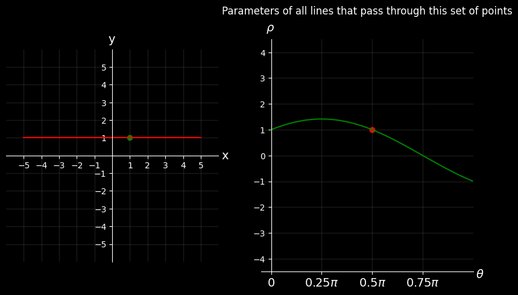

png

```python
fig, ax = plt.subplots(1,2, figsize=(10, 5))

# Point On Image Space
image_space_point = [1, 1]

xs = np.arange(-5, 5 + 1, 1)
ys = line_image_space(xs, 0, 1)

plot_points_and_lines_with_grid(
    ax[0],
    scatter_arg_kwarg_pair = [(), {
        "x": [image_space_point[0]],
        "y": [image_space_point[1]],
        "c": ["g"],
    }],
    line_arg_kwarg_pairs=[
        [(xs, ys), {"color": "r"}]
    ]
)

# Plot on Parameter Space

degrees = np.arange(0, 180, 1)
line_thetas = np.deg2rad(degrees)
line_rhos = normal_form_line_parameter_space(line_thetas, 1, 1)


rho = 1
theta = np.arccos(0/rho)

ax[1].set_title("Parameters of all lines that pass through this set of points", pad=30)

plot_points_and_lines_with_grid_theta_rho(
    ax[1],
    scatter_arg_kwarg_pair = [(), {
        "x": [theta],
        "y": [rho],
        "c": ["r"],
    }],
    line_arg_kwarg_pairs=[
        [(line_thetas, line_rhos), {"color": "g"}]
    ]
)

plt.show()
```

### A line becomes a point

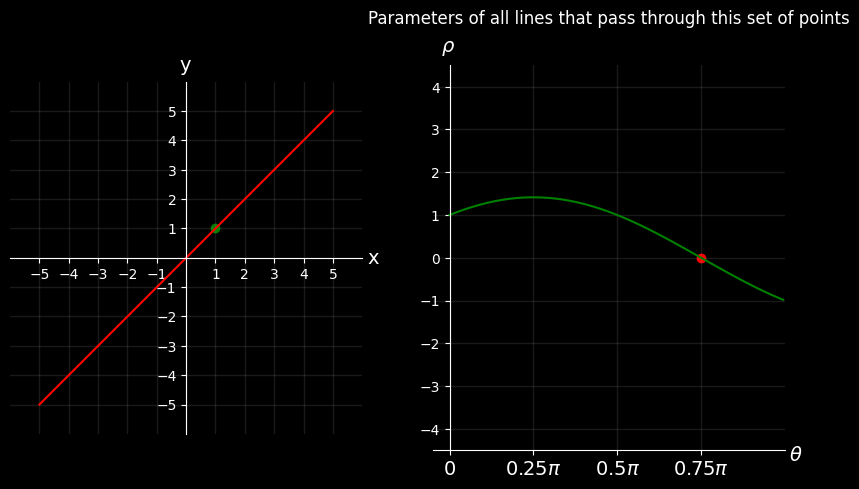

png

```python
fig, ax = plt.subplots(1,2, figsize=(10, 5))

# Point On Image Space
image_space_point = [1, 1]

xs = np.arange(-5, 5 + 1, 1)
ys = line_image_space(xs, 1, 0)

plot_points_and_lines_with_grid(
    ax[0],
    scatter_arg_kwarg_pair = [(), {
        "x": [image_space_point[0]],
        "y": [image_space_point[1]],
        "c": ["g"],
    }],
    line_arg_kwarg_pairs=[
        [(xs, ys), {"color": "r"}]
    ]
)

# Plot on Parameter Space

degrees = np.arange(0, 180, 1)
line_thetas = np.deg2rad(degrees)
line_rhos = normal_form_line_parameter_space(line_thetas, 1, 1)


rho = 0
theta = np.arccos(-1/np.sqrt(1**2 + 1**2))

ax[1].set_title("Parameters of all lines that pass through this set of points", pad=30)

plot_points_and_lines_with_grid_theta_rho(
    ax[1],
    scatter_arg_kwarg_pair = [(), {
        "x": [theta],
        "y": [rho],
        "c": ["r"],
    }],
    line_arg_kwarg_pairs=[
        [(line_thetas, line_rhos), {"color": "g"}]
    ]
)

plt.show()
```

关于如何在上图画出垂直线段，参考下图：

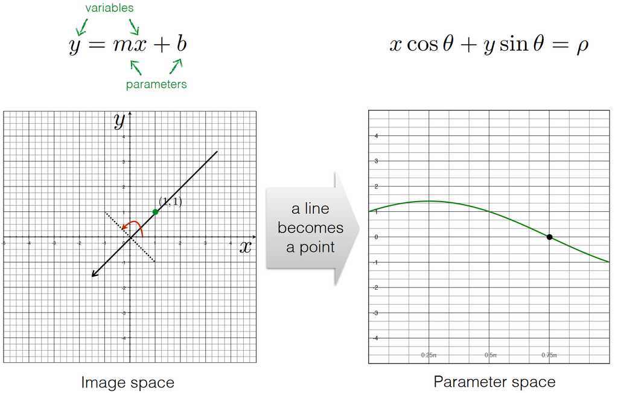

### Why rho is negative?

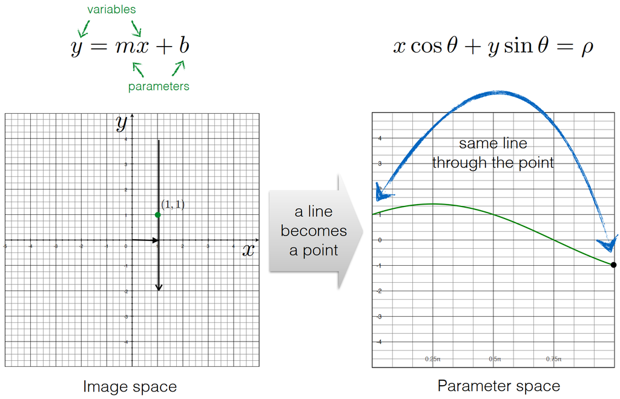

上图中的右图，点 $(\theta = 0, \rho = 1)$ 和点 $(\theta = \pi, \rho = -1$) 表示同一条直线；$\rho$ 为负数是因为方向不同，造成的 $\theta$ 值不同，从而导致 $\rho$ 符号变化，具体见：

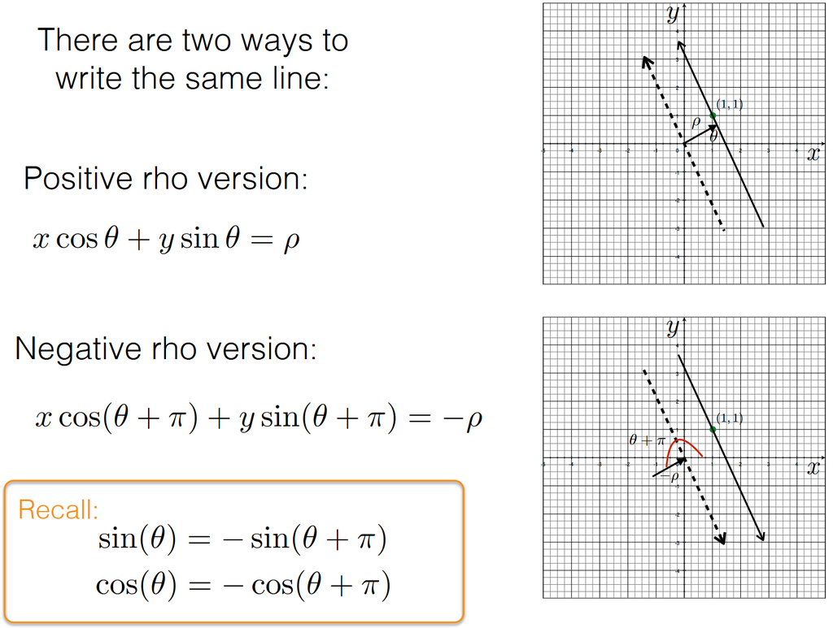

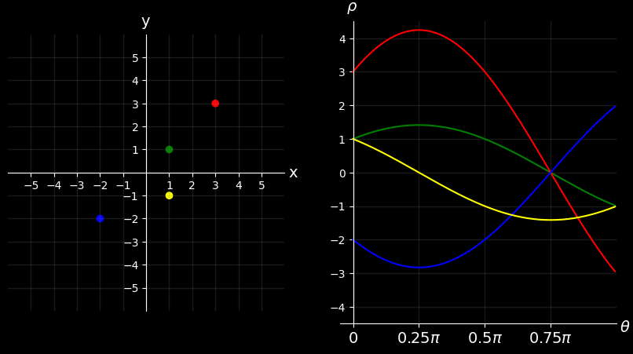

png

```python
fig, ax = plt.subplots(1,2, figsize=(10, 5))

# Point On Image Space
image_space_point = [1, 1]

# Plot On Image Space
pts = [[1, 1], [3, 3], [-2, -2], [1, -1]]
colors = ["green", "red", "blue", "yellow"]

xs = [pt[0] for pt in pts]
ys = [pt[1] for pt in pts]

plot_points_and_lines_with_grid(
    ax[0],
    scatter_arg_kwarg_pair = [(), {
        "x": xs,
        "y": ys,
        "c": colors,
    }],
)

# Plot on Parameter Space

degrees = np.arange(0, 180, 1)
thetas = np.deg2rad(degrees)

line_arg_kwarg_pairs = [[(thetas.copy(), normal_form_line_parameter_space(thetas.copy(), x, y)), {"color": color}] for x, y, color in zip(xs, ys, colors)]

plot_points_and_lines_with_grid_theta_rho(
    ax[1],
    line_arg_kwarg_pairs=line_arg_kwarg_pairs
)

plt.show()
```

## 实现

1. Initialize accumulator H to all zeros
2. For each edge point $(x, y)$ in the image
   - For $\theta=0$ to 180
     - $\rho=x \cos \theta+y \sin \theta$
     - $H(\theta, \rho)=H(\theta, \rho)+1$
   - end

   end
3. Find the value(s) of $(\theta, \rho)$ where $H(\theta, \rho)$ is a local maximum
4. The detected line in the image is given by $\rho=x \cos \theta+y \sin \theta$

以下是来自 https://alyssaq.github.io/2014/understanding-hough-transform/ 的实现

```python
## Implementation

import numpy as np

def hough_line_np(img):
  # Rho and Theta ranges
  thetas = np.deg2rad(np.arange(-90.0, 90.0))
  width, height = img.shape
  diag_len = int(np.ceil(np.sqrt(width * width + height * height)))   # max_dist
  rhos = np.linspace(-diag_len, diag_len, diag_len * 2)

  # Cache some resuable values
  cos_t = np.cos(thetas)
  sin_t = np.sin(thetas)
  num_thetas = len(thetas)

  # Hough accumulator array of theta vs rho
  accumulator = np.zeros((2 * diag_len, num_thetas), dtype=np.uint64)
  y_idxs, x_idxs = np.nonzero(img)  # (row, col) indexes to edges

  # Vote in the hough accumulator
  for i in range(len(x_idxs)):
    x = x_idxs[i]
    y = y_idxs[i]

    for t_idx in range(num_thetas):
      # Calculate rho. diag_len is added for a positive index
      rho = round(x * cos_t[t_idx] + y * sin_t[t_idx]) + diag_len
      accumulator[rho, t_idx] += 1

  return accumulator, thetas, rhos


## Usage

# Create binary image and call hough_line
image = np.zeros((50,50))
image[10:40, 10:40] = np.eye(30)
accumulator, thetas, rhos = hough_line_np(image)

# Easiest peak finding based on max votes
idx = np.argmax(accumulator)
rho = rhos[int(idx / accumulator.shape[1])]
theta = thetas[idx % accumulator.shape[1]]
print("rho={0:.2f}, theta={1:.0f}".format(rho, np.rad2deg(theta)))
```

```
rho=0.50, theta=-45
```

## 使用OpenCV

```python
img = np.zeros((192, 192), dtype=np.uint8)

points = [[100, 100], [120, 120], [150, 150], [180, 180], [142, 23]]

for i, j in points:
    img[i, j] = 255

Image.fromarray(img)
```

[output not shown]

png

```python
lines = cv2.HoughLines(img, 1, np.pi / 180, 2)

cdst = img.copy()

# Draw the lines
if lines is not None:
    for i in range(0, len(lines)):
        rho = lines[i][0][0]
        theta = lines[i][0][1]
        print(theta, rho)
        a = np.cos(theta)
        b = np.sin(theta)
        x0 = a * rho
        y0 = b * rho
        pt1 = (int(x0 + 1000*(-b)), int(y0 + 1000*(a)))
        pt2 = (int(x0 - 1000*(-b)), int(y0 - 1000*(a)))

        cv2.line(cdst, pt1, pt2, (255,255,255), 1, cv2.LINE_AA)

Image.fromarray(cdst)
```

```
2.3561945 0.0
```

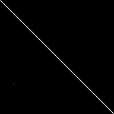

png

上面的代码中

$$a = \cos \theta \\
b = \sin \theta$$

其中，根据定义，向量$(a, b)$与直线构建的向量是垂直的，那么直线可以表示为$v=(-b,a)$的向量（相乘为0）。

根据直线公式公式

$$\mathbf{r} = \mathbf{r}_0 + t \mathbf{v}$$

上面的代码中`pt1`和`pt2`分别为$t=1000$和$t=-1000$时计算的

## 使用scikit-image

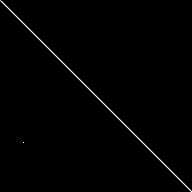

png

```python
from skimage.transform import hough_line, hough_line_peaks
hspace, angles, dists = hough_line(img)
hspace, angles, dists = hough_line_peaks(hspace, angles, dists)

img_display = img.copy()

for _, angle, dist in zip(hspace, angles, dists):
    a = np.cos(angle)
    b = np.sin(angle)
    (x0, y0) = dist * np.array([a, b])
    pt1 = (int(x0 + 1000*(-b))), int(y0 + 1000*(a))
    pt2 = (int(x0 - 1000*(-b))), int(y0 - 1000*(a))

    cv2.line(img_display, pt1, pt2, (255,255,255), 1, cv2.LINE_AA)

Image.fromarray(img_display)
```

## 参考资料

- https://www.cs.cmu.edu/~16385/s17/Slides/5.3_Hough_Transform.pdf
- https://alyssaq.github.io/2014/understanding-hough-transform/
- https://gist.github.com/bygreencn/6a900fd2ff5d0101473acbc3783c4d92
- https://docs.opencv.org/4.x/d9/db0/tutorial_hough_lines.html
- https://scikit-image.org/docs/stable/auto_examples/edges/plot_line_hough_transform.html